# Sun Haven: More Mana

“Phung (foom) Tran”

# Introduction

Sun Haven is a farming rpg similar to more popular titles such as Stardew Valley and Harvest Moon. Players must balance there time between farming, crafting, and exploration to improve their farm and player stats. By permanently boosting your stats, such as mana, players can optimize there gameplay.

# Questions I wanted to ask?

What are some crops or cooked foods that we can focus on in Spring and starting town?

After first year gameplay, what can players focus on in Spring to see what can be prepared to boost our mana?

What cooked foods give us the biggest amounts of mana?

```r
# Loading libraires used

library(tidyverse) # Loads R packages for data manipulation and visualization
library(ggplot2) # Used to create graphs/charts
library(janitor) # Used to help clean data
library(wesanderson) # Color palettes from Wes Anderson movies
library(extrafont) # Loaded in more fonts
library(gridExtra) # Create a 2x2 grid for plots
library(grid) # Used to change font for gridExtra
library(cowplot) # Clean
```

```r
# Loading in data that will be used

cooked_food <- read.csv('Sun Haven Cooked Food.csv')

animal_product <- read.csv('Sun Haven Farm Animal.csv')

fish <- read.csv("Sun Haven Fish.csv")

foragables <- read.csv('Sun Haven Foragables.csv')

crops <- read.csv('Sun Haven Crops.csv')
```

```r
# Convert all columns to character, clean missing values ("", "N/A", "N A"), and process numeric columns

cooked_food <- cooked_food %>%
  mutate(across(everything(), as.character)) %>%
  mutate(across(everything(), ~ na_if(., ""))) %>% # for string values
  mutate(sell_price = as.numeric(sell_price), # convert any number columns into numeric
         mp = as.numeric(mp),
         hp = as.numeric(hp)) %>%
  mutate(across(where(is.character), ~ na_if(., "N/A"))) %>%  # Replace "N/A" with NA
  mutate(across(where(is.character), ~ na_if(., "N A"))) %>%   # Replace "N A" with NA
  mutate(across(where(is.character), ~ gsub("amount", "", .)))  # Remove "amount"
```

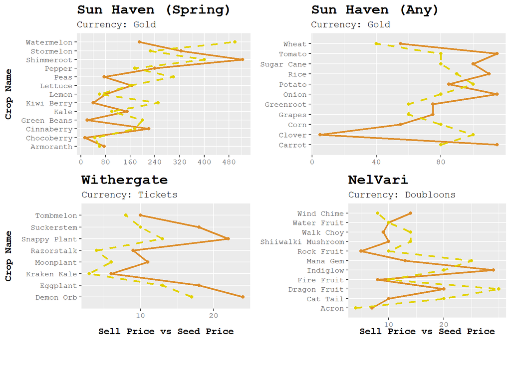

These charts help us narrow down what crops we can grow if we just started the game. Specifically looking at fig.1 and fig.2. Fig. 3 and 4 are more useful when have gone through the first year of game play. While money is not the main thing we’re looking for in the data, it is useful information to help decide a starting point.

Next, we can look at all the stations that is used to cook food. You can tell that the starting station, cooking pot, has the most recipes that are available to you at the beginning of the game. By looking at this chart, you’re starting town, Sun Haven, has more recipes for you to choose from.

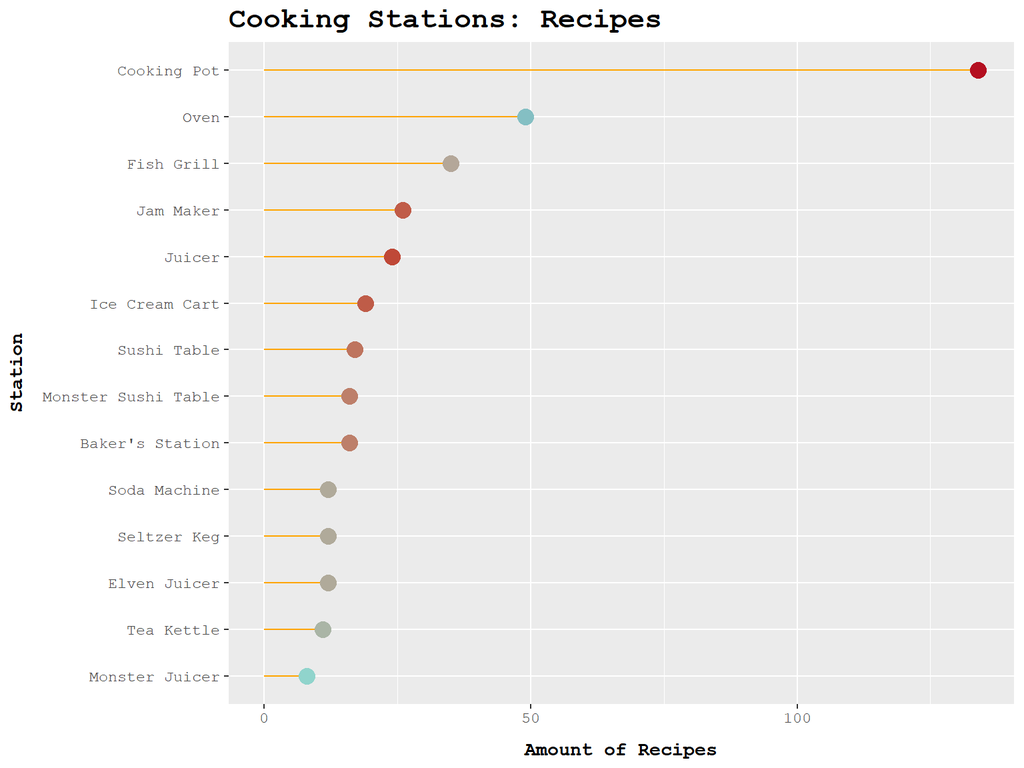

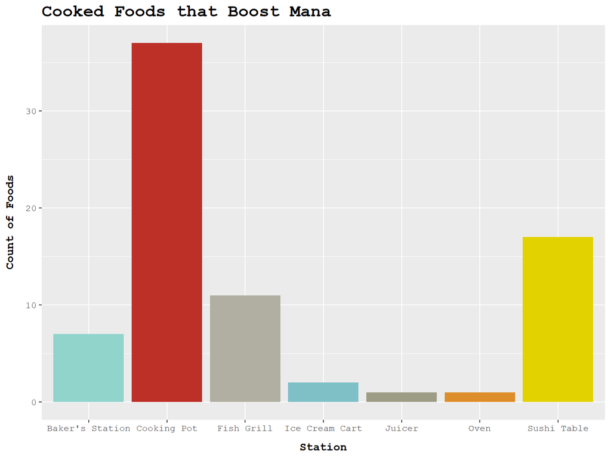

By narrowing it down to only looking at recipes that permanently boost your mana, we can see that the cooking pot still has the most options available to you.

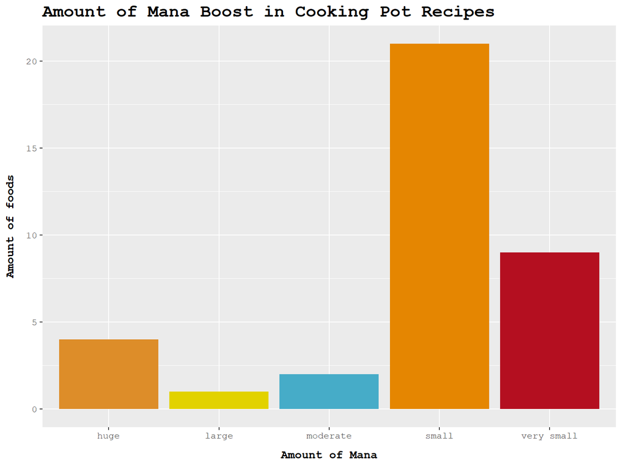

From here, we can see the cooking pot has bias towards “small” stat boost available to us. However, we can also see that we do have recipes that give us “huge” permanent stat boost

```
## # A tibble: 4 × 8
##   station item  currency stat  stat_boost ingredient_1 ingredient_2 ingredient_3
##   <chr>   <chr> <chr>    <chr> <chr>      <chr>        <chr>        <chr>
## 1 Cookin… Gold… Mana Orb Mana  huge       Golden Fire… Noodles      Greenspice
## 2 Cookin… Gold… Mana Orb Mana  huge       Golden Fath… Mushroom     Seaweed
## 3 Cookin… Gold… Mana Orb Mana  huge       Golden Mush… Bread        Tomato
## 4 Cookin… Gold… Mana Orb Mana  huge       Golden Brin… Golden Tren… Golden Naut…
```

These “huge” mana stat boost items contain “Golden” in the name as well as ingredients listed that are not possible to obtain early on. With the currency being “Mana Orb”, the town Nel’Vari would have to be available to the player.

By filtering the search down further, there are more early game accessible items.

```
## # A tibble: 10 × 7
##    station     item   currency stat_boost ingredient_1 ingredient_2 ingredient_3
##    <chr>       <chr>  <chr>    <chr>      <chr>        <chr>        <chr>
##  1 Cooking Pot Blueb… Gold     small      Blueberry    Lettuce      <NA>
##  2 Cooking Pot Pickl… Gold     small      Lettuce      Tomato       Greenspice
##  3 Cooking Pot Sesam… Gold     small      Rice         Seaweed      <NA>
##  4 Cooking Pot Mochi  Gold     small      Rice         Sugar        <NA>
##  5 Cooking Pot Lasag… Gold     moderate   Noodles      Tomato       Cheese
##  6 Cooking Pot Apple… Gold     small      Apple        Sugar        Cinnaberry
##  7 Cooking Pot Cinna… Gold     small      Cinnaberry   Apple        Sugar
##  8 Cooking Pot BLT    Gold     small      Bread        Lettuce      Tomato
##  9 Cooking Pot Poke … Gold     small      Salmon       Tuna         Rice
## 10 Cooking Pot Churr… Gold     very small Cinnaberry   Flour        Sugar
```

# Conclusion

If the player is starting gameplay, a filtered search looking at recipes with:

Sun Haven (starting town), Spring

Gives players a large amount of items that can be made at to permanently increase their mana stats.

A more generalized search can help players optimize resource management after first year gameplay.

In both instances, players can figure out farm and storage layout as well as where they would like to focus more of their time to increase the mana stat in order to more efficiently play the game.